# Stock Analysis with Quantmod

## Analysis of Stock Trends and Visualizations

The tools used are R packages quantmod and Quandl.

List of Stocks:

Google (GOOG), Amazon (AMZN), Bank of America (BAC), Gold (GLD)

List of Functions and Common Indicators:

addSMA() - Simple Moving Average, addMACD() - Moving Average Convergence Divergence, addBBands() - Bollinger Bands, addCCI() - Commodity channel index, addADX() - Directional Movement Indicator, addCMF() - Add Chaiken Money Flow

For others, see https://en.wikipedia.org/wiki/Technical_analysis

```r
## install.packages("quantmod")
library(quantmod)
```

The getSymbols function loads (downloads) historic price data Usage.

## ^GSPC - S&P 500

[output not shown]

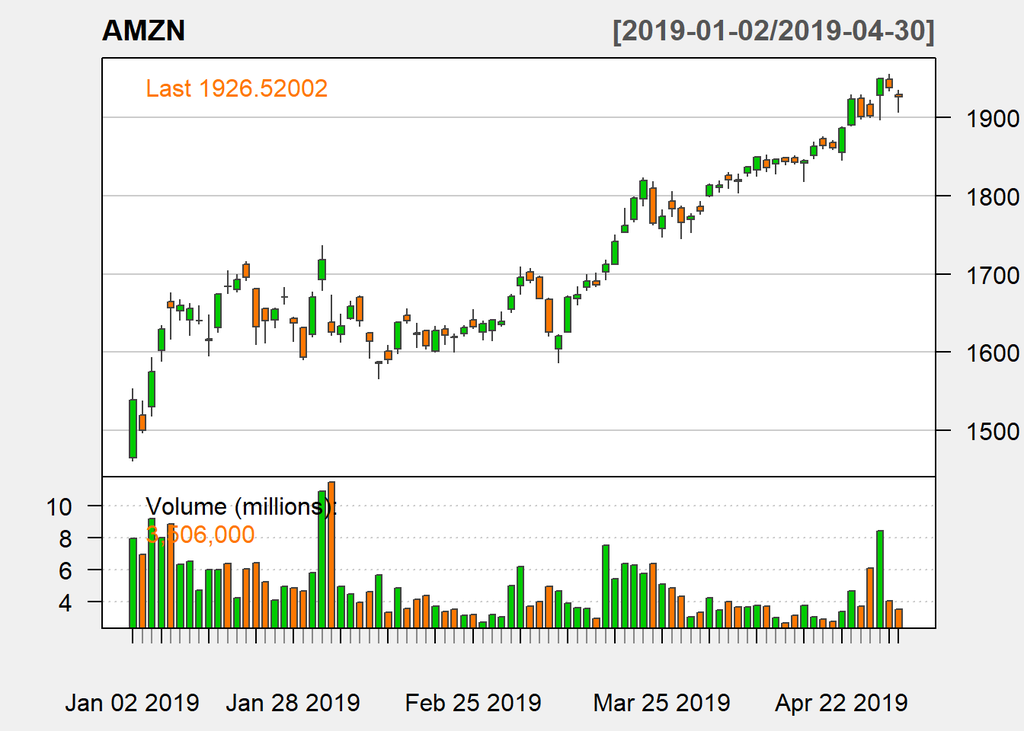

```r
chartSeries(AMZN,subset="2019",theme="white")
```

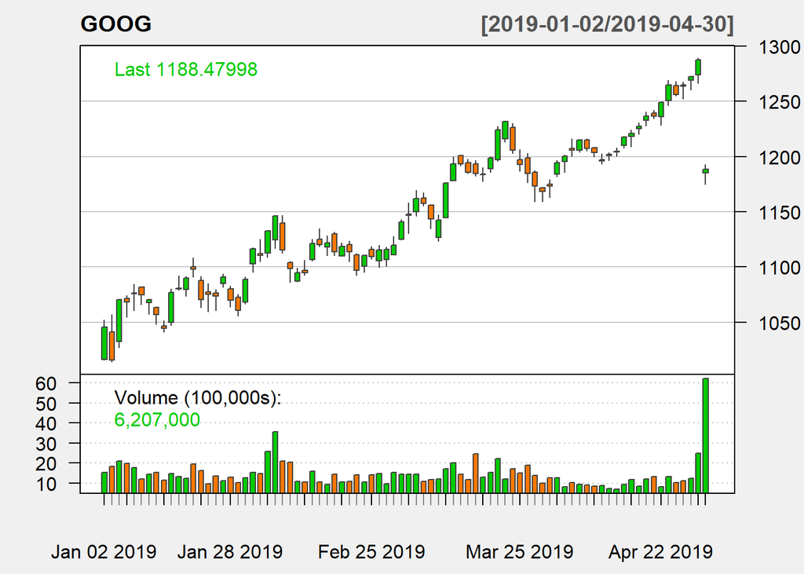

```r
chartSeries(GOOG,subset="2019",theme="white")
```

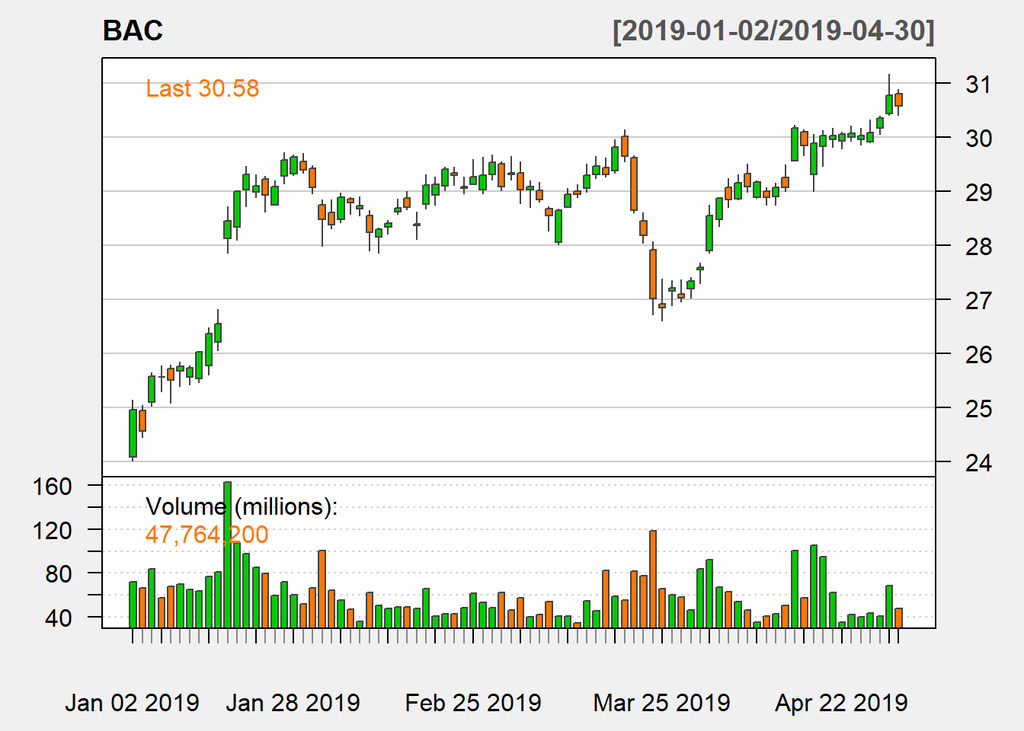

```r
chartSeries(BAC,subset="2019",theme="white")
```

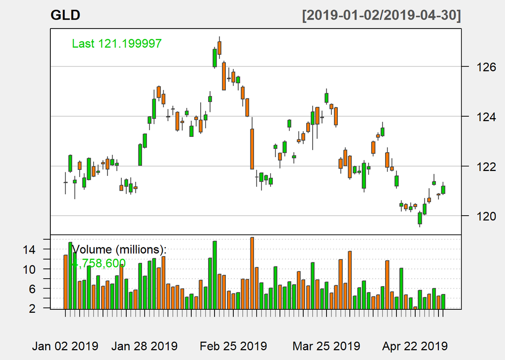

```r
chartSeries(GLD,subset="2019",theme="white")
```

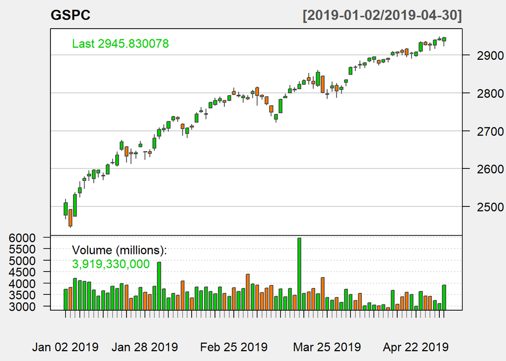

```r
chartSeries(GSPC,subset="2019",theme="white")
```

Design (theme) changes to make more visible

```r
whiteTheme <- chartTheme("white")

## List of desig options in "theme" function
names(whiteTheme)
```

```
##  [1] "fg.col"       "bg.col"       "grid.col"     "border"       "minor.tick"
##  [6] "major.tick"   "up.col"       "dn.col"       "dn.up.col"    "up.up.col"
## [11] "dn.dn.col"    "up.dn.col"    "up.border"    "dn.border"    "dn.up.border"
## [16] "up.up.border" "dn.dn.border" "up.dn.border" "main.col"     "sub.col"
## [21] "area"         "fill"         "Expiry"       "theme.name"
```

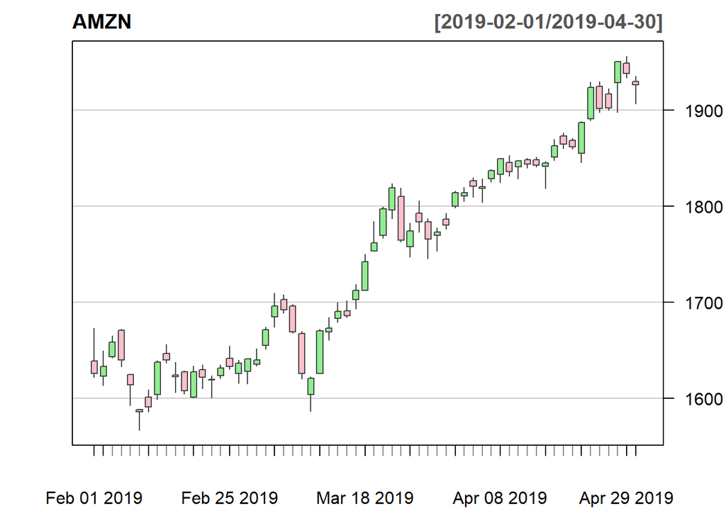

```r
whiteTheme$bg.col <- "white"
whiteTheme$dn.col <- "pink"
whiteTheme$up.col <- "lightgreen"
whiteTheme$border <- "lightgray"
x1 <- chartSeries(AMZN,subset="last 3 months",theme=whiteTheme,TA=NULL)
```

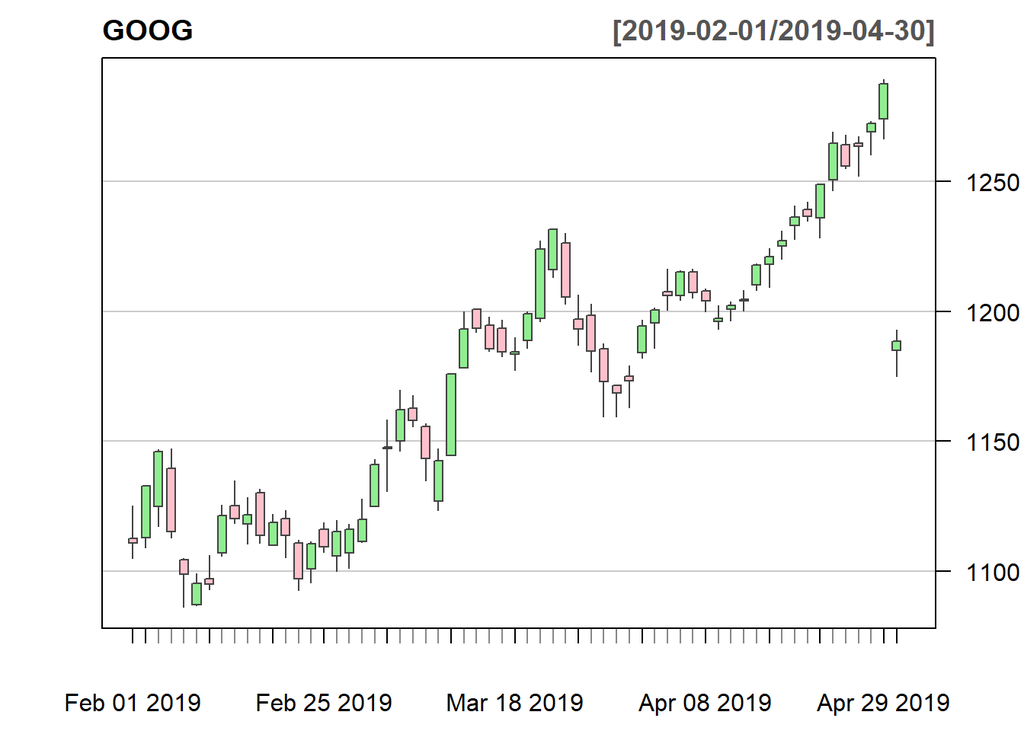

```r
x2 <- chartSeries(GOOG,subset="last 3 months",theme=whiteTheme,TA=NULL)
```

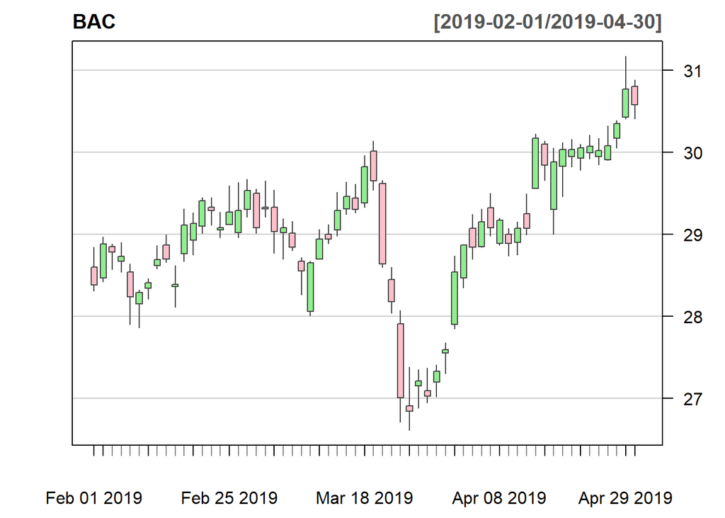

```r
x3 <- chartSeries(BAC,subset="last 3 months",theme=whiteTheme,TA=NULL)
```

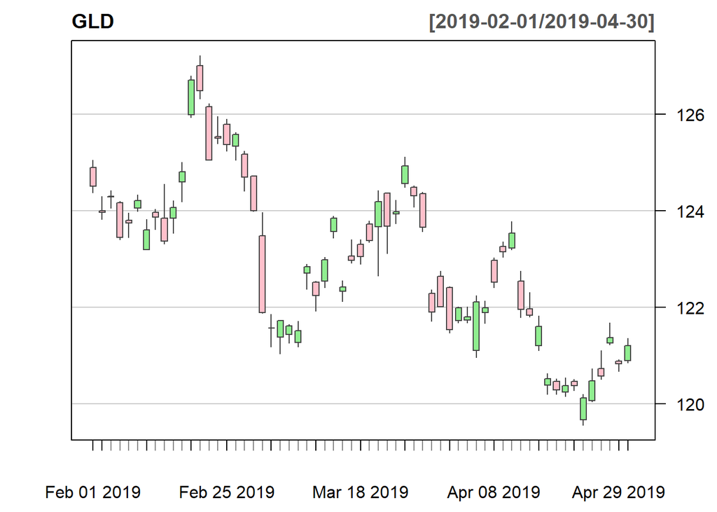

```r
x4 <- chartSeries(GLD,subset="last 3 months",theme=whiteTheme,TA=NULL)
```

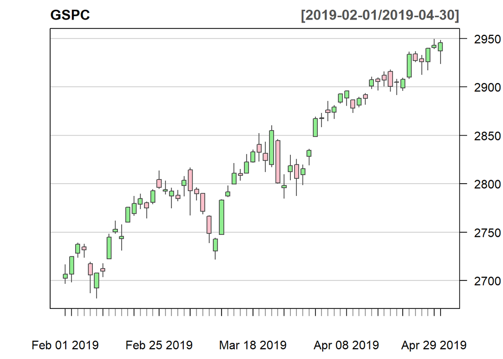

```r
x5 <- chartSeries(GSPC,subset="last 3 months",theme=whiteTheme,TA=NULL)
```

```r
class(x1)
```

```
## [1] "chob"
## attr(,"package")
## [1] "quantmod"
```

```r
class(x2)
```

```
## [1] "chob"
## attr(,"package")
## [1] "quantmod"
```

```r
class(x3)
```

```
## [1] "chob"
## attr(,"package")
## [1] "quantmod"
```

```r
class(x4)
```

```
## [1] "chob"
## attr(,"package")
## [1] "quantmod"
```

```r
class(x5)
```

```
## [1] "chob"
## attr(,"package")
## [1] "quantmod"
```

Provide title for chart:

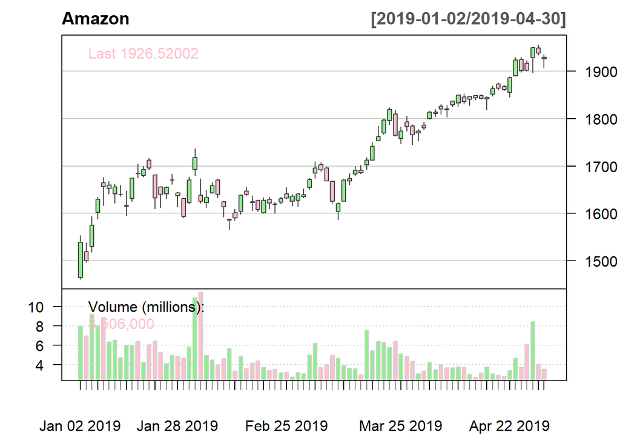

```r
chartSeries(AMZN["2019"],theme=whiteTheme,name="Amazon")
```

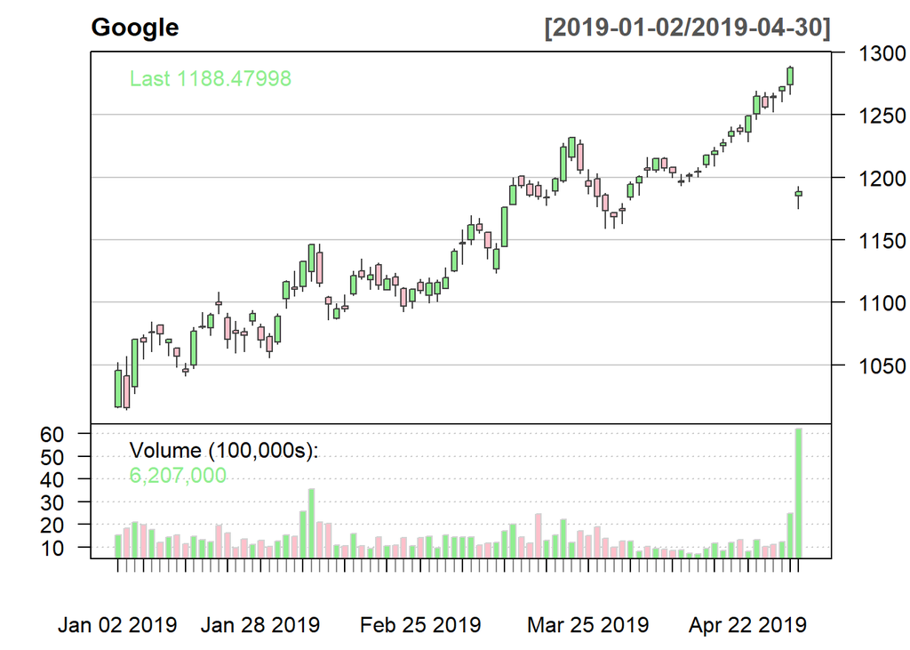

```r
chartSeries(GOOG["2019"],theme=whiteTheme,name="Google")
```

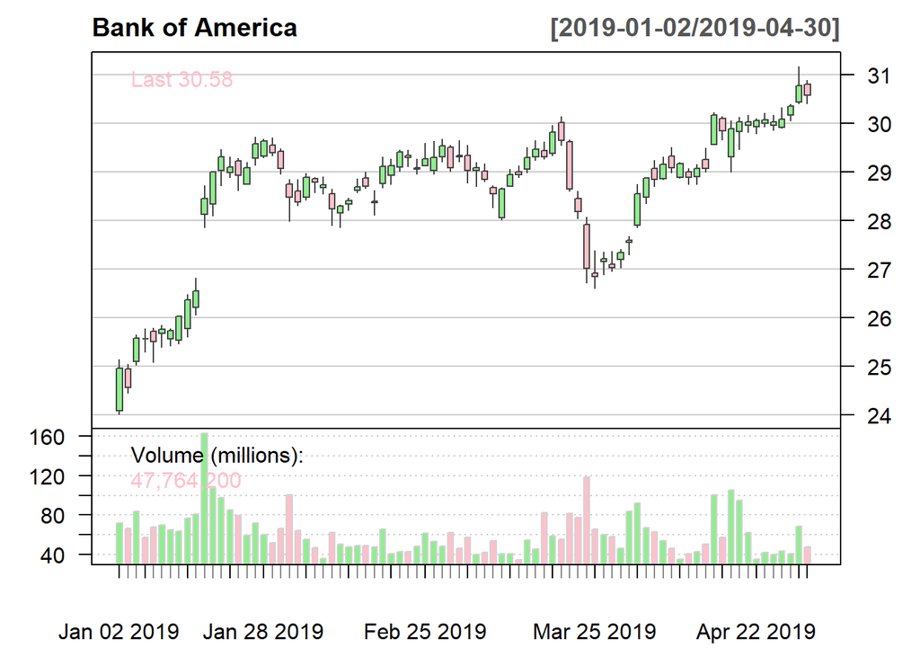

```r
chartSeries(BAC["2019"],theme=whiteTheme,name="Bank of America")
```

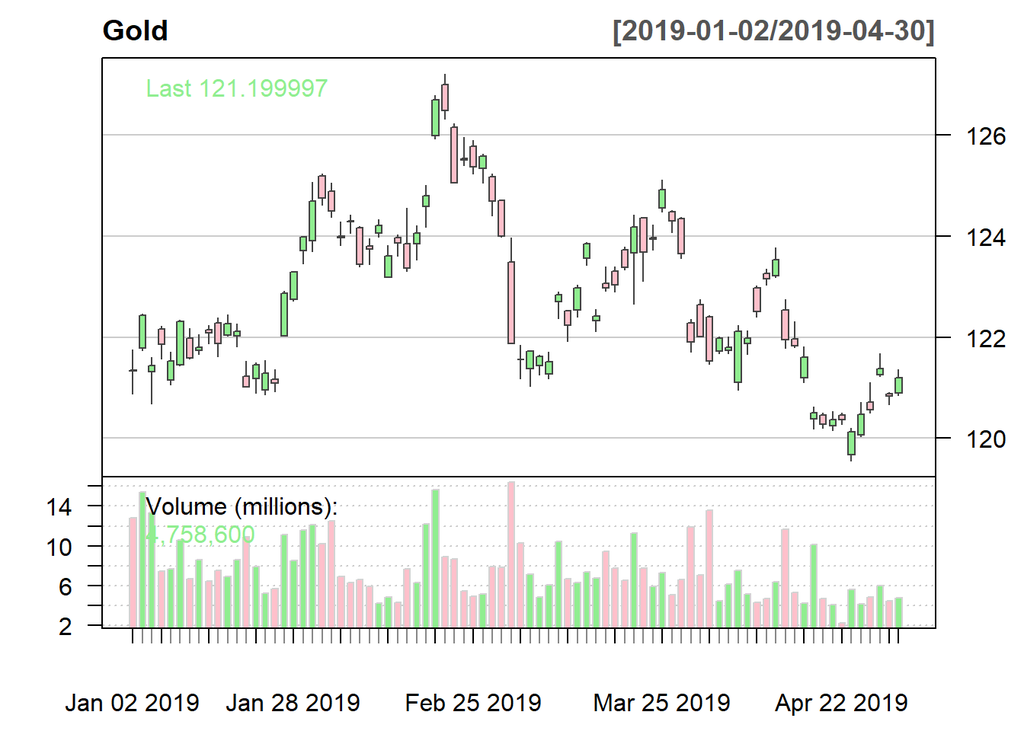

```r
chartSeries(GLD["2019"],theme=whiteTheme,name="Gold")
```

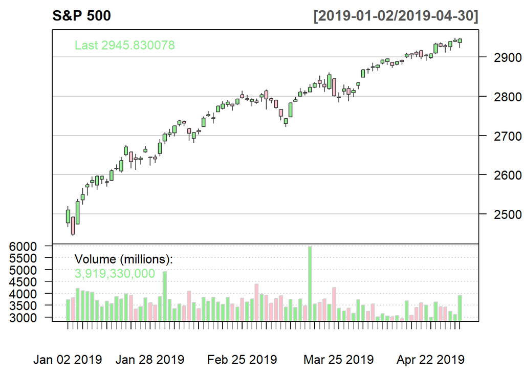

```r
chartSeries(GSPC["2019"],theme=whiteTheme,name="S&P 500")
```

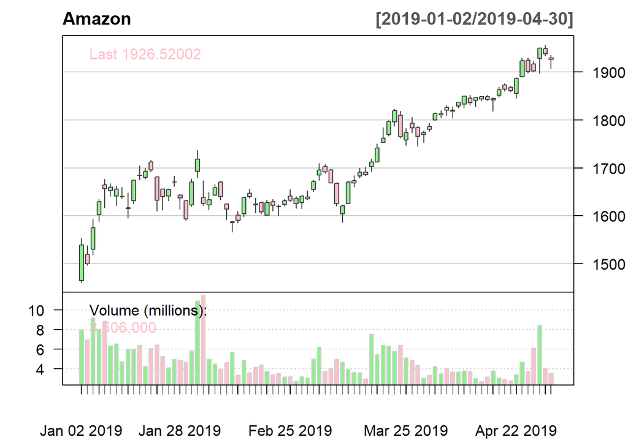

```r
chartSeries(AMZN["2018/2019"],theme=whiteTheme,name="Amazon")
```

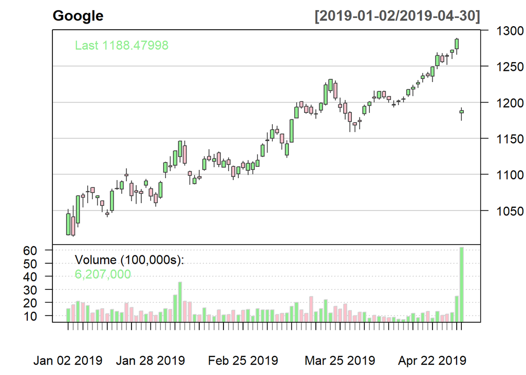

```r
chartSeries(GOOG["2018/2019"],theme=whiteTheme,name="Google")
```

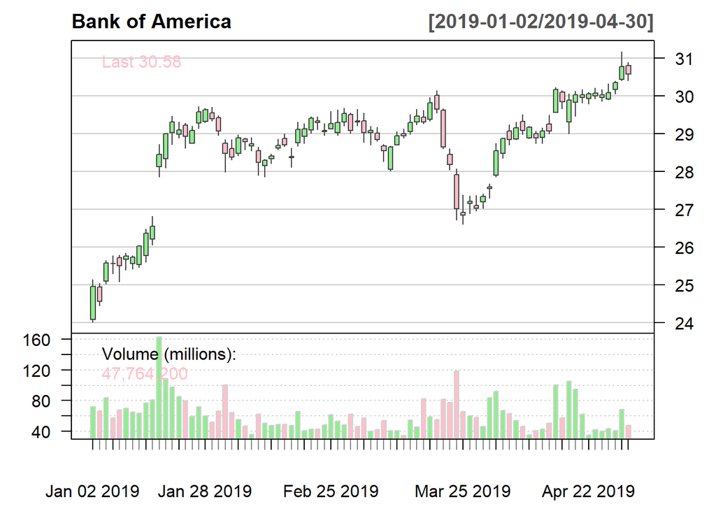

```r
chartSeries(BAC["2018/2019"],theme=whiteTheme,name="Bank of America")
```

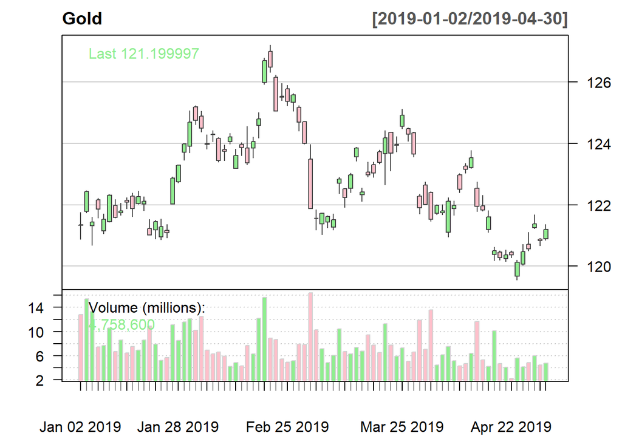

```r
chartSeries(GLD["2018/2019"],theme=whiteTheme,name="Gold")
```

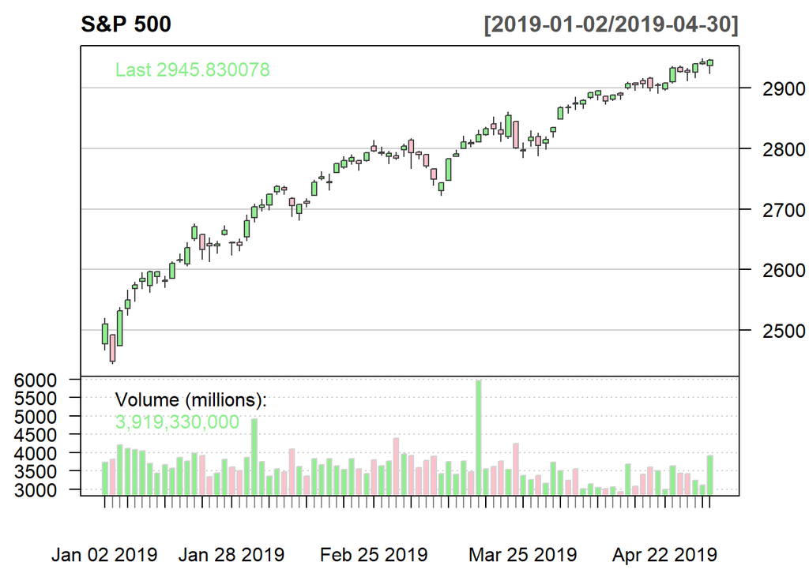

```r
chartSeries(GSPC["2018/2019"],theme=whiteTheme,name="S&P 500")
```

Comparing the median return ratios:

```r
returnAMZN<-annualReturn(AMZN, subset="2018/2019")
median(returnAMZN)
```

```
## [1] 0.3148513
```

```r
returnGOOG<-annualReturn(GOOG, subset="2018/2019")
median(returnGOOG)
```

```
## [1] 0.1691079
```

```r
returnBAC<-annualReturn(BAC, subset="2018/2019")
median(returnBAC)
```

```
## [1] 0.2699336
```

```r
returnGLD<-annualReturn(GLD, subset="2018/2019")
median(returnGLD)
```

```
## [1] -0.001236102
```

```r
returnGSPC<-annualReturn(GSPC, subset ="2018/2019")
median(returnGSPC)
```

```
## [1] 0.1892926
```

SPY is a S&P 500 ETF (exchange traded fund). An ETF is traded on a major stock exchange—like the New York Stock Exchange or Nasdaq. It is a basket of stocks, in this case all the individual stocks on the S&P 500

```r
getSymbols("SPY", from="2019-01-01")
```

```
## [1] "SPY"
```

```r
class(SPY)
```

```
## [1] "xts" "zoo"
```

```r
head(SPY)
```

```
##            SPY.Open SPY.High SPY.Low SPY.Close SPY.Volume SPY.Adjusted
## 2019-01-02   245.98   251.21  245.95    250.18  126925200     243.0259
## 2019-01-03   248.23   248.57  243.67    244.21  144140700     237.2266
## 2019-01-04   247.59   253.11  247.17    252.39  142628800     245.1727
## 2019-01-07   252.69   255.95  251.69    254.38  103139100     247.1058
## 2019-01-08   256.82   257.31  254.00    256.77  102512600     249.4274
## 2019-01-09   257.56   258.91  256.19    257.97   95006600     250.5931
```

Chart Item together for comparison

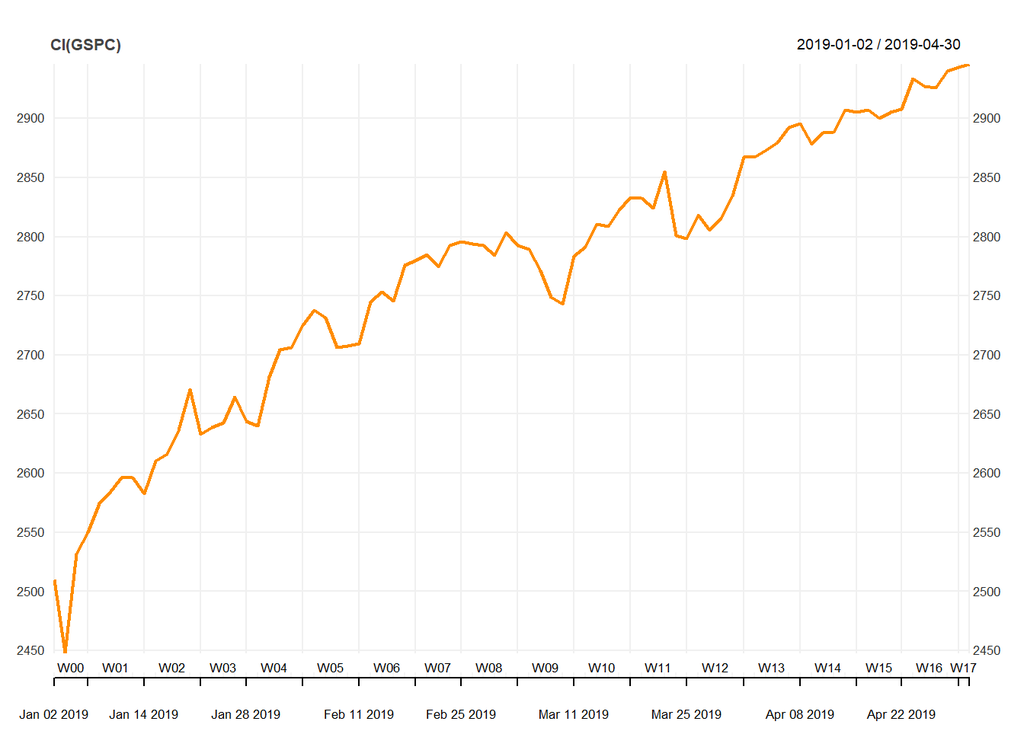

```r
chart_Series(Cl(GSPC), subset = "2019")
```

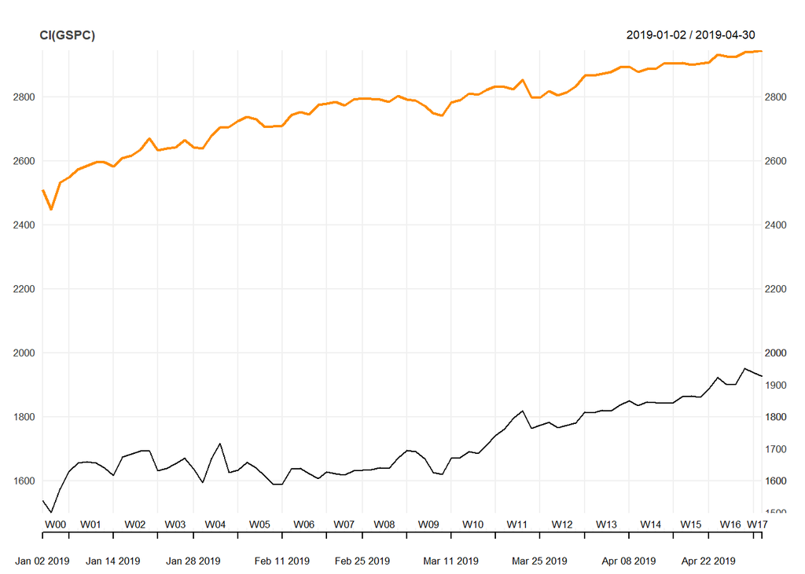

```r
add_TA(Cl(AMZN), on = 1, col = "black")
```

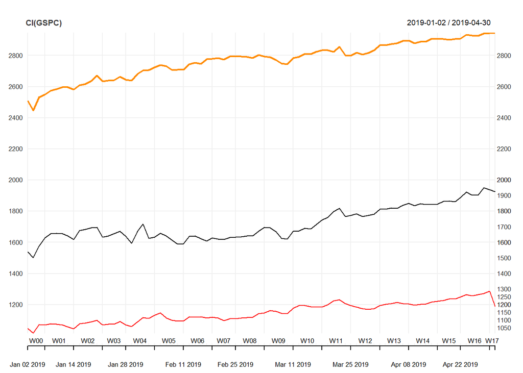

```r
add_TA(Cl(GOOG), on = 1, col = "red")
```

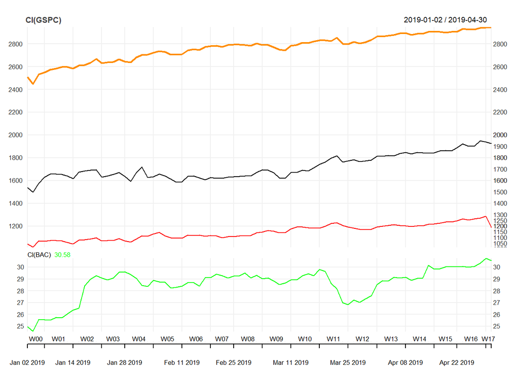

```r
add_TA(Cl(BAC), on = NA, col = "green")
```

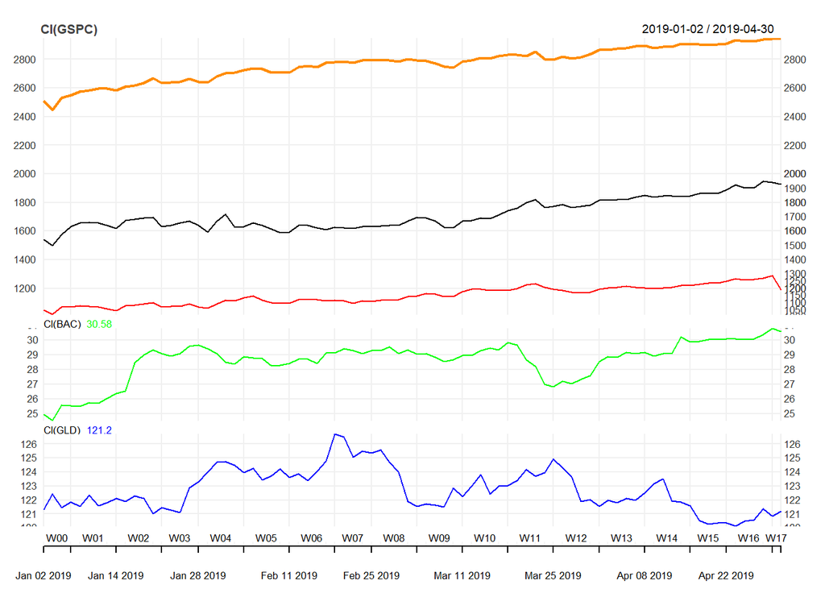

```r
add_TA(Cl(GLD), on = NA, col = "blue")
```

Combine additional securities with normalization

To see relative changes more easily, you can normalise your price series in many ways. This is a typical approach (using a 0 origin is what Google charts does):

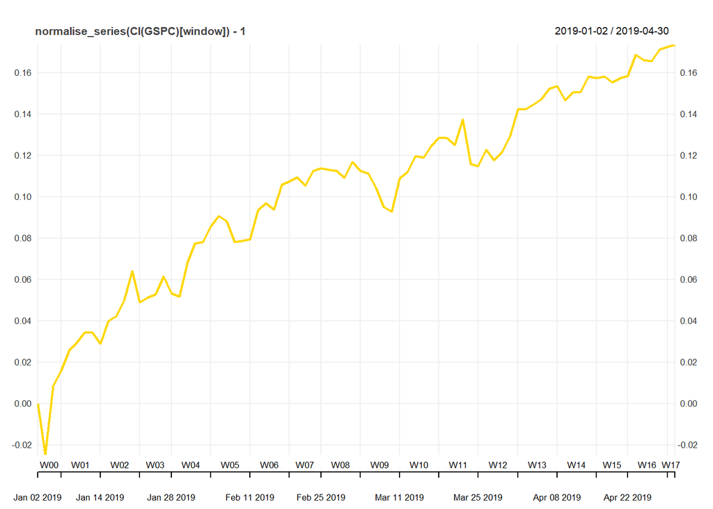

```r
normalise_series <- function(xdat) xdat / coredata(xdat)[1]
window <- "2019/"

# Define colour of default chart line to chart_Series in mytheme object
# which is passed to chart_Series:
mytheme <- chart_theme()
mytheme$col$line.col <- "gold"
chart_Series(normalise_series(Cl(GSPC)[window]) - 1, theme = mytheme)
```

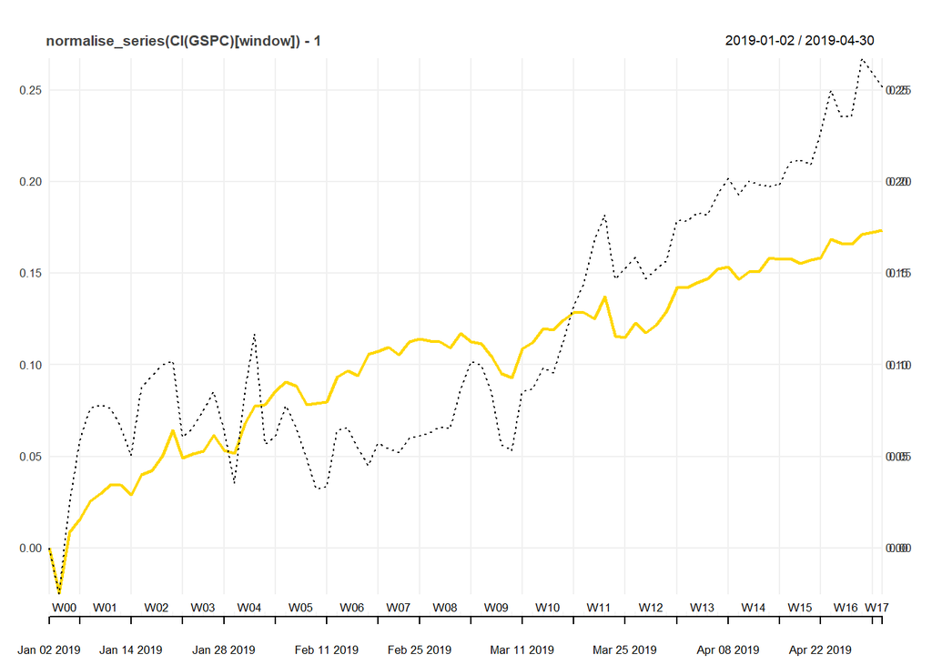

```r
add_TA(normalise_series(Cl(AMZN)[window]) - 1, on = 1, col = "black", lty = 3)
```

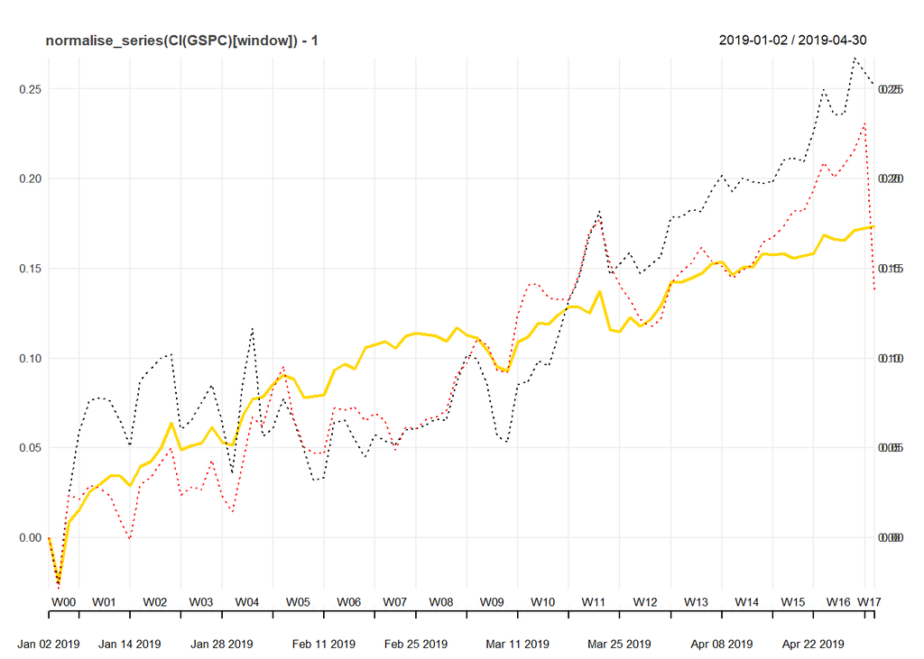

```r
add_TA(normalise_series(Cl(GOOG)[window]) - 1, on = 1, col = "red", lty = 3)
```

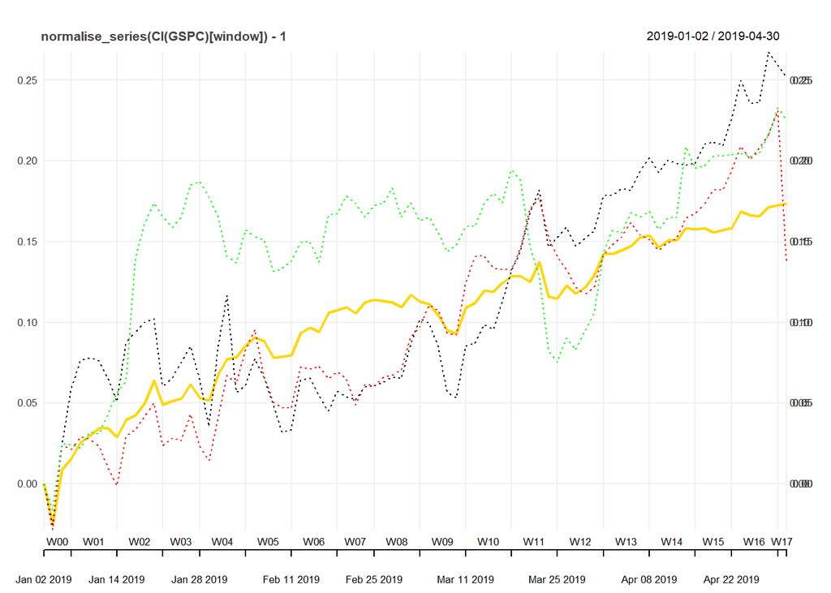

```r
add_TA(normalise_series(Cl(BAC)[window]) - 1, on = 1, col = "green", lty = 3)
```

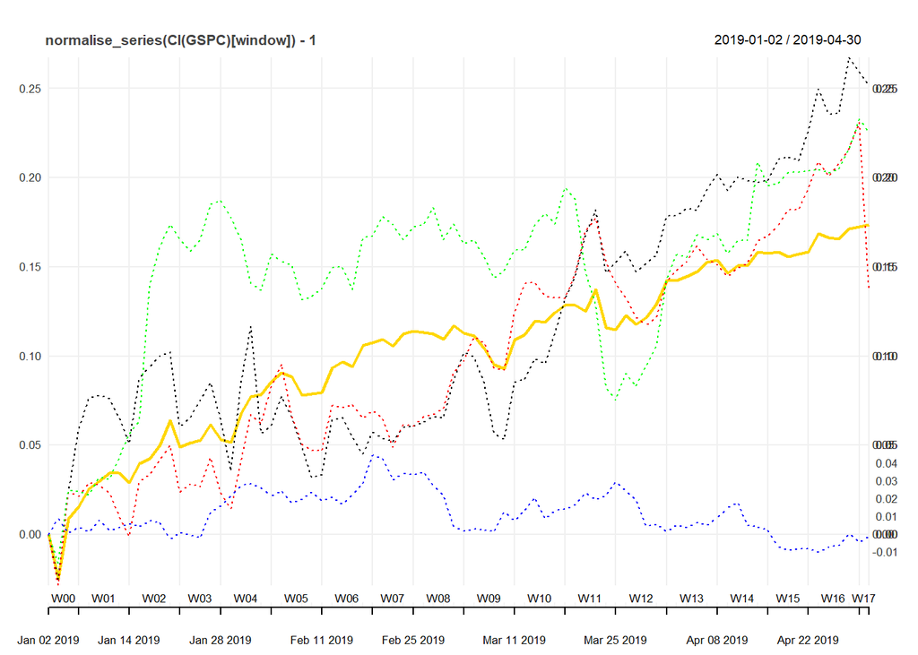

```r
add_TA(normalise_series(Cl(GLD)[window]) - 1, on = 1, col = "blue", lty = 3)
```

```r
# Or add RSIs on different subpanels to improve readability of charts:
#add_TA(RSI(Cl(AMZN)), on = NA, col = "black")
#add_TA(RSI(Cl(GOOG)), on = 2, col = "red", lty = 3)
#add_TA(RSI(Cl(BAC)), on = NA, col = "green", lty = 2)
#add_TA(RSI(Cl(GLD)), on = NA, col = "blue", lty = 2)
#add_TA(RSI(Cl(GSPC)), on = NA, col = "orange", lty = 2)
```

Get Stock Dividends

```r
(div <- getDividends("GOOG"))
```

```
##      GOOG.div
```

Get Returns (Profit or Loss from beginning of period)

```r
# Quick returns - quantmod style

## getSymbols("SBUX")
dreturns<-dailyReturn(GOOG) # returns by day
head(dreturns)
```

```
##            daily.returns
## 2019-01-02   0.028802708
## 2019-01-03  -0.028483988
## 2019-01-04   0.053786157
## 2019-01-07  -0.002166736
## 2019-01-08   0.007384957
## 2019-01-09  -0.001505180
```

```r
wreturns<-weeklyReturn(GOOG) # returns by week
summary(wreturns)
```

```
##      Index            weekly.returns
##  Min.   :2019-01-04   Min.   :-0.065793
##  1st Qu.:2019-02-02   1st Qu.:-0.005701
##  Median :2019-03-04   Median : 0.016083
##  Mean   :2019-03-04   Mean   : 0.009092
##  3rd Qu.:2019-04-03   3rd Qu.: 0.028525
##  Max.   :2019-04-30   Max.   : 0.053257
```

```r
mreturns<-monthlyReturn(GOOG) # returns by month, indexed by yearmon
mreturns
```

```
##            monthly.returns
## 2019-01-31     0.098173256
## 2019-02-28     0.003179993
## 2019-03-29     0.047673060
## 2019-04-30     0.012929166
```

All Returns summary compared

```r
# daily,weekly,monthly,quarterly, and yearly
allreturns<-allReturns(GSPC) # note the plural
summary(allreturns)
```

```
##      Index                daily               weekly            monthly
##  Min.   :2019-01-02   Min.   :-0.024757   Min.   :-0.02162   Min.   :0.01792
##  1st Qu.:2019-01-31   1st Qu.:-0.001131   1st Qu.: 0.00088   1st Qu.:0.02678
##  Median :2019-03-02   Median : 0.001376   Median : 0.00907   Median :0.03452
##  Mean   :2019-03-01   Mean   : 0.002007   Mean   : 0.00977   Mean   :0.04467
##  3rd Qu.:2019-03-31   3rd Qu.: 0.006609   3rd Qu.: 0.02179   3rd Qu.:0.05241
##  Max.   :2019-04-30   Max.   : 0.034336   Max.   : 0.02895   Max.   :0.09170
##                       NA's   :1           NA's   :64         NA's   :78
##    quarterly           yearly
##  Min.   :0.03931   Min.   :0.1893
##  1st Qu.:0.06556   1st Qu.:0.1893
##  Median :0.09181   Median :0.1893
##  Mean   :0.09181   Mean   :0.1893
##  3rd Qu.:0.11806   3rd Qu.:0.1893
##  Max.   :0.14431   Max.   :0.1893
##  NA's   :80        NA's   :81
```

Get Price Earnings ratio:

```r
getQuote("AMZN", what = yahooQF("P/E Ratio"))
```

```
##               Trade Time P/E Ratio
## AMZN 2020-08-31 16:00:01  132.5406
```

```r
getQuote("GOOG", what = yahooQF("P/E Ratio"))
```

```
##               Trade Time P/E Ratio
## GOOG 2020-08-31 16:00:02  35.92236
```

```r
getQuote("BAC", what = yahooQF("P/E Ratio"))
```

```
##              Trade Time P/E Ratio
## BAC 2020-08-31 16:00:01  12.38691
```

```r
getQuote("GLD", what = yahooQF("P/E Ratio"))
```

```
##              Trade Time P/E Ratio
## GLD 2020-08-31 16:00:00        NA
```

```r
getQuote("^GSPC", what = yahooQF("P/E Ratio"))
```

```
##                Trade Time P/E Ratio
## ^GSPC 2020-08-31 17:14:37        NA
```

Get Price Earnings Ratio:

```r
require(quantmod)
require("plyr")
what_metrics <- yahooQF(c("Price/Sales",
                          "P/E Ratio",
                          "Price/EPS Estimate Next Year",
                          "PEG Ratio",
                          "Dividend Yield",
                          "Market Capitalization"))

tickers <- c("AAPL", "GOOG", "AMZN", "BAC", "GS")
# Not all the metrics are returned by Yahoo.
metrics <- getQuote(paste(tickers, sep="", collapse=";"), what=what_metrics)

#Add tickers as the first column and remove the first column which had date stamps
metrics <- data.frame(Symbol=tickers, metrics[,2:length(metrics)])

#Change colnames
colnames(metrics) <- c("Symbol", "P/E Ratio", "P/E EPS next year", "Div Yield", "Market Cap")

head(metrics,10)
```

```
##      Symbol P/E Ratio P/E EPS next year   Div Yield   Market Cap
## AAPL   AAPL  39.15048          8.303732 0.006265649 2.206906e+12
## GOOG   GOOG  35.92236         28.974823          NA 1.109794e+12
## AMZN   AMZN 132.54060         78.199860          NA 1.728551e+12
## BAC     BAC  12.38691         12.084506 0.027376428 2.230139e+11
## GS       GS  15.45372          8.961942 0.024217766 7.049085e+10
```

```r
#Persist this to the csv file
## write.csv(metrics, "FinancialMetrics.csv", row.names=FALSE)
```

Use Quandl to get gross domestic product

```r
# install.packages("Quandl")
library(Quandl)
# Import GDP data from FRED
Quandl.api_key("szb8F2ei__rwj7mD3ugt")
gdp <- Quandl(code = "FRED/GDP")

# Look at the structure of the object returned by Quandl

str(gdp)
```

```
## 'data.frame':    294 obs. of  2 variables:
##  $ Date : Date, format: "2020-04-01" "2020-01-01" ...
##  $ Value: num  19487 21561 21747 21540 21330 ...
##  - attr(*, "freq")= chr "quarterly"
```

```r
head(gdp,20)
```

```
##          Date    Value
## 1  2020-04-01 19486.51
## 2  2020-01-01 21561.14
## 3  2019-10-01 21747.39
## 4  2019-07-01 21540.33
## 5  2019-04-01 21329.88
## 6  2019-01-01 21115.31
## 7  2018-10-01 20909.85
## 8  2018-07-01 20742.72
## 9  2018-04-01 20552.65
## 10 2018-01-01 20242.22
## 11 2017-10-01 19937.96
## 12 2017-07-01 19617.29
## 13 2017-04-01 19379.23
## 14 2017-01-01 19237.44
## 15 2016-10-01 19032.58
## 16 2016-07-01 18821.36
## 17 2016-04-01 18656.21
## 18 2016-01-01 18470.16
## 19 2015-10-01 18378.80
## 20 2015-07-01 18347.42
```

Download interest rate (DTB3) and GDP (Gross Domestic Product) data from FRED DTB3 = 3 month treasury bill

```r
getSymbols('DTB3',src='FRED')
```

```
## [1] "DTB3"
```

```r
first(DTB3,'1 week')
```

```
##            DTB3
## 1954-01-04 1.33
## 1954-01-05 1.28
## 1954-01-06 1.28
## 1954-01-07 1.31
## 1954-01-08 1.31
```

```r
getSymbols('GDP',src='FRED') ## quarterly
```

```
## [1] "GDP"
```